# Assignment Report

Muhammad Hafiz Hasan

January 31, 2016

# Executive Summary

Using devices such as Jawbone Up, Nike FuelBand, and Fitbit it is now possible to collect a large amount of data about personal activity relatively inexpensively. These type of devices are part of the quantified self movement - a group of enthusiasts who take measurements about themselves regularly to improve their health, to find patterns in their behavior, or because they are tech geeks. One thing that people regularly do is quantify how much of a particular activity they do, but they rarely quantify how well they do it.

The aim of this report is to predict how well the six participants in doing the exercises based on data from accelerometers placed on the belt, forearm, arm and dumbell.

### Libraries

Following are the required libraries

```r
library(caret)
library(corrplot)
library(kernlab)
library(knitr)
library(randomForest)
```

### Loading and preprocessing the data

Two csv files contatining the training and test data for this analysis purposes.

```r
# check if a data folder exists; if not then create one
if (!file.exists("data-source")) {dir.create("data-source")}

# file URL and destination file
training_url <- "https://d396qusza40orc.cloudfront.net/predmachlearn/pml-training.csv"
training_ds <- "./data-source/pml-training.csv"
testing_url <- "https://d396qusza40orc.cloudfront.net/predmachlearn/pml-testing.csv"
testing_ds <- "./data-source/pml-testing.csv"

# download the file and note the time
download.file(training_url, destfile = training_ds)
download.file(testing_url, destfile = testing_ds)
date_downloaded <- date()
```

The training data was then loaded into R.

```r
# read the csv file for training
data_training <- read.csv("./data-source/pml-training.csv", na.strings= c("NA",""," "))
```

```r
# clean the data by removing columns with NAs etc
data_training_NAs <- apply(data_training, 2, function(x) {sum(is.na(x))})
data_training_clean <- data_training[,which(data_training_NAs == 0)]

# remove identifier columns such as name, timestamps etc
data_training_clean <- data_training_clean[8:length(data_training_clean)]
```

### Creating a model

```r
# split the cleaned testing data into training and cross validation
in_train <- createDataPartition(y = data_training_clean$classe, p = 0.7, list = FALSE)
training <- data_training_clean[in_train, ]
crossval <- data_training_clean[-in_train, ]
```

A random forest model was selected to predict the classification because it has methods for balancing error in class population unbalanced data sets. The correlation between any two trees in the forest increases the forest error rate. Therefore, a correllation plot was produced in order to see how strong the variables relationships are with each other.

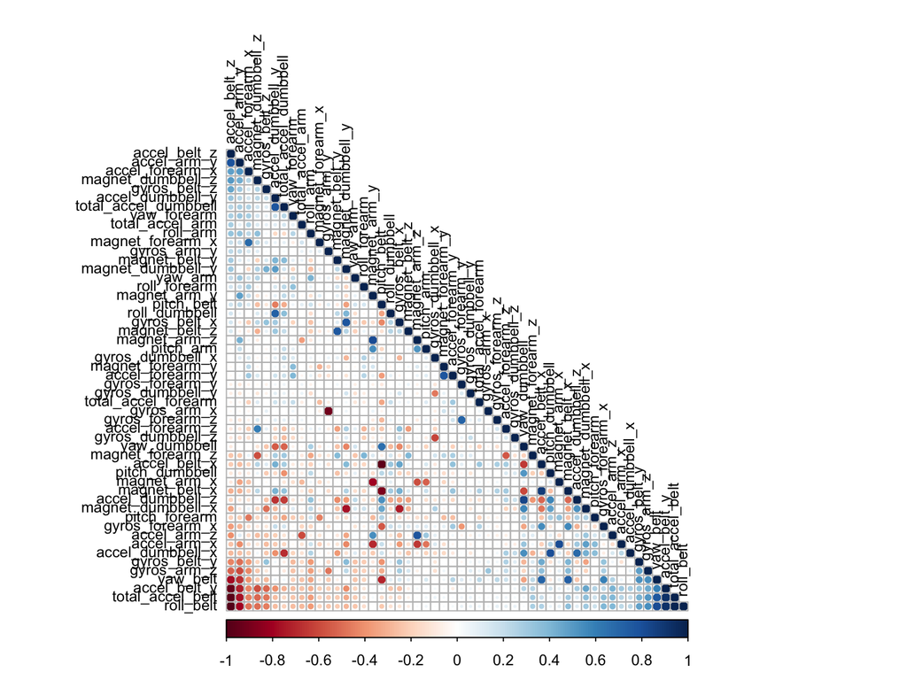

```r
# plot a correlation matrix
correlation_matrix <- cor(training[, -length(training)])
corrplot(correlation_matrix, order = "FPC", method = "circle", type = "lower", tl.cex = 0.8,  tl.col = rgb(0, 0, 0))
```

In this type of plot the dark red and blue colours indicate a highly negative and positive relationship respectively between the variables. There isn’t much concern for highly correlated predictors which means that all of them can be included in the model.

Then a model was fitted with the outcome set to the training class and all the other variables used to predict.

```r
# fit a model to predict the classe using everything else as a predictor
model <- randomForest(classe ~ ., data = training)
model
```

```
##
## Call:
##  randomForest(formula = classe ~ ., data = training)
##                Type of random forest: classification
##                      Number of trees: 500
## No. of variables tried at each split: 7
##
##         OOB estimate of  error rate: 0.53%
## Confusion matrix:
##      A    B    C    D    E  class.error
## A 3903    2    1    0    0 0.0007680492
## B    8 2643    7    0    0 0.0056433409
## C    0   14 2381    1    0 0.0062604341
## D    0    0   26 2224    2 0.0124333925
## E    0    0    2   10 2513 0.0047524752
```

### Cross-validation

The model was then used to classify the remaining 30% of data. The results were placed in a confusion matrix along with the actual classifications in order to determine the accuracy of the model.

```r
# crossvalidate the model using the remaining 30% of data
predict_cross_value <- predict(model, crossval)
confusionMatrix(crossval$classe, predict_cross_value)
```

```
## Confusion Matrix and Statistics
##
##           Reference
## Prediction    A    B    C    D    E
##          A 1672    1    0    0    1
##          B    6 1130    3    0    0
##          C    0    7 1015    4    0
##          D    0    0    7  957    0
##          E    0    0    2    0 1080
##
## Overall Statistics
##
##                Accuracy : 0.9947
##                  95% CI : (0.9925, 0.9964)
##     No Information Rate : 0.2851
##     P-Value [Acc > NIR] : < 2.2e-16
##
##                   Kappa : 0.9933
##  Mcnemar's Test P-Value : NA
##
## Statistics by Class:
##
##                      Class: A Class: B Class: C Class: D Class: E
## Sensitivity            0.9964   0.9930   0.9883   0.9958   0.9991
## Specificity            0.9995   0.9981   0.9977   0.9986   0.9996
## Pos Pred Value         0.9988   0.9921   0.9893   0.9927   0.9982
## Neg Pred Value         0.9986   0.9983   0.9975   0.9992   0.9998
## Prevalence             0.2851   0.1934   0.1745   0.1633   0.1837
## Detection Rate         0.2841   0.1920   0.1725   0.1626   0.1835
## Detection Prevalence   0.2845   0.1935   0.1743   0.1638   0.1839
## Balanced Accuracy      0.9980   0.9955   0.9930   0.9972   0.9993
```

### Predictions

A separate data set was then loaded into R and cleaned in the same manner as before. The model was then used to predict the classifications of the 20 results of this new data.

```r
# apply the same treatment to the final testing data
data_test <- read.csv("./data-source/pml-testing.csv", na.strings= c("NA",""," "))
data_test_NAs <- apply(data_test, 2, function(x) {sum(is.na(x))})
data_test_clean <- data_test[,which(data_test_NAs == 0)]
data_test_clean <- data_test_clean[8:length(data_test_clean)]

# predict the classes of the test set
prediction_test <- predict(model, data_test_clean)
prediction_test
```

```
##  1  2  3  4  5  6  7  8  9 10 11 12 13 14 15 16 17 18 19 20
##  B  A  B  A  A  E  D  B  A  A  B  C  B  A  E  E  A  B  B  B
## Levels: A B C D E
```

### Conclusions

With the abundance of information given from multiple measuring instruments it’s possible to accurately predict how well a person is preforming an excercise using a relatively simple model.